# Global Flight Route Density Mapping - Complete Beginner’s Guide

Author

Nimesh Akalanka (Enhanced for Beginners)

## 🎯 What You’ll Create

By the end of this tutorial, you’ll have a beautiful, professional map showing **where airplanes fly most frequently around the world**. Think of it like a heat map - brighter colors show busier flight routes!

**Perfect for**: Beginners in data visualization, geography students, aviation enthusiasts, or anyone wanting to learn R programming.

## 📋 Overview

### What This Tutorial Does (In Simple Terms)

1. **Downloads real flight data** from the internet (airports and routes)
2. **Processes the data** to connect airports with flight paths
3. **Creates a hexagon grid** over the world map (like a honeycomb)
4. **Counts how many flights** pass through each hexagon
5. **Makes a colorful map** showing flight density

### Types of Routes We’ll Create

**Curved Routes** 🌐: Realistic paths following Earth’s spherical surface (how planes actually fly!)

**NoteWhy Curved Routes Matter**

Imagine you’re flying from New York to Tokyo. On a flat map, the shortest path looks like it goes straight across the Pacific Ocean. But Earth is round! The actual shortest path curves up through Alaska. That’s what geodetic (curved) routes show.

## 🛠️ Prerequisites

### What is R?

**R** is a free programming language designed for statistics and data visualization. Think of it as Microsoft Excel on steroids - it can handle millions of data points and create professional visualizations.

### What You Need to Install

1. **R** (the programming language): Download from [r-project.org](https://www.r-project.org/)
2. **RStudio** (makes R easier to use): Download from [posit.co](https://posit.co/download/rstudio-desktop/)

### Install Required R Packages

Run this code **once** to install everything:

```r
# Install all required packages
install.packages(c("readr", "dplyr", "stringr", "sf", "ggplot2", "viridis", "scales", "rnaturalearth", "rnaturalearthdata","geosphere", "tmap"
))
```

**TipInstallation Time**

This may take 5-10 minutes depending on your internet speed. Be patient!

### Load Libraries

After installing packages once, you need to “load” them each time you start R:

```r
# Load all libraries we'll use
library(readr)
library(dplyr)
library(stringr)
library(sf)
library(ggplot2)
library(viridis)
library(scales)
library(rnaturalearth)
library(geosphere)
library(tmap)

cat("✓ All libraries loaded successfully!\n")
```

```
✓ All libraries loaded successfully!
```

## 📂 Step 1: Download and Prepare Airport Data

### Create Folder Structure

```r
# Create two folders: one for outputs, one for raw data
folders <- c("output", "data")
sapply(folders, dir.create, showWarnings = FALSE, recursive = TRUE)
```

```
output   data
  TRUE   TRUE
```

```r
cat("✓ Folders created successfully!\n")
```

```
✓ Folders created successfully!
```

### Download Airport Data

```r
# Check if we already have the airports file
if (!file.exists("data/airports.dat")) {
  cat("📥 Downloading airports.dat...\n")

  download.file(
    url = "https://raw.githubusercontent.com/jpatokal/openflights/master/data/airports.dat",
    destfile = "data/airports.dat",
    mode = "wb"
    )
  cat("✓ Airports downloaded!\n")
} else {
  cat("✓ Airports file already exists. Skipping download.\n")
}
```

```
📥 Downloading airports.dat...
✓ Airports downloaded!
```

### Download Routes Data

```r
# Check if we already have the routes file
if (!file.exists("data/routes.dat")) {
  cat("📥 Downloading routes.dat...\n")

  download.file(
    url = "https://raw.githubusercontent.com/jpatokal/openflights/master/data/routes.dat",
    destfile = "data/routes.dat",
    mode = "wb"
  )
  cat("✓ Routes downloaded!\n")
} else {
  cat("✓ Routes file already exists. Skipping download.\n")
}
```

```
📥 Downloading routes.dat...
✓ Routes downloaded!
```

### Load Routes Data

```r
# Define column names for routes
routes_column <- c("Airline","Airline_ID", "Source_airport", "Source_airport_ID","Destination_airport","Destination_airport_ID", "Codeshare", "Stops", "Equipment")

# Read the routes file
routes <- read_delim(
  "data/routes.dat",
  delim = ",",
  col_names = routes_column,
  show_col_types = FALSE
)

# Save a copy as CSV
write_csv(routes, "output/routes.csv")

cat("✓ Loaded", nrow(routes), "routes from the database\n")
```

```
✓ Loaded 67663 routes from the database
```

### Load Airports Data

```r
# Define column names for airports
airports_column <- c(
  "Airport_ID", "Name", "City", "Country", "IATA", "ICAO",
  "Latitude", "Longitude", "Altitude", "Timezone", "DST",
  "Tz_database_timezone", "Type", "Source"
)

# Read the airports file
airports <- read_delim(
  "data/airports.dat",
  delim = ",",
  col_names = airports_column,
  show_col_types = FALSE
)

# Save a copy as CSV
write_csv(airports, "output/airports.csv")

cat("✓ Loaded", nrow(airports), "airports from the database\n")
```

```
✓ Loaded 7698 airports from the database
```

```r
cat("\n📍 Sample airports:\n")
```

```
📍 Sample airports:
```

```r
print(head(airports %>% select(Name, City, Country, IATA, Latitude, Longitude), 5))
```

```
# A tibble: 5 × 6
  Name                                    City  Country IATA  Latitude Longitude
  <chr>                                   <chr> <chr>   <chr>    <dbl>     <dbl>
1 Goroka Airport                          Goro… Papua … GKA      -6.08      145.
2 Madang Airport                          Mada… Papua … MAG      -5.21      146.
3 Mount Hagen Kagamuga Airport            Moun… Papua … HGU      -5.83      144.
4 Nadzab Airport                          Nadz… Papua … LAE      -6.57      147.
5 Port Moresby Jacksons International Ai… Port… Papua … POM      -9.44      147.
```

### Convert Airports to Spatial Format

```r
# Convert to spatial object
airports_sf <- airports %>%
  mutate(
    Latitude = as.numeric(Latitude),
    Longitude = as.numeric(Longitude)
  ) %>%
  filter(!is.na(Latitude), !is.na(Longitude)) %>%
  st_as_sf(coords = c("Longitude", "Latitude"), crs = 4326, remove = FALSE)

# Transform to Equal Earth projection
airports_sf <- st_transform(airports_sf, crs = 8857)

# Save as shapefile
st_write(airports_sf, "output/airports.shp", append = FALSE, quiet = TRUE)

cat("✓ Created spatial object with", nrow(airports_sf), "airports\n")
```

```
✓ Created spatial object with 7698 airports
```

## 🛫 Step 2: Create Geodetic (Curved) Route Lines

### Clean Routes Data

```r
# Clean the routes data
routes_clean <- routes %>%
  mutate(
    Source_airport = str_trim(Source_airport),
    Destination_airport = str_trim(Destination_airport)
  ) %>%
  filter(
    !is.na(Source_airport), !is.na(Destination_airport),
    Source_airport != "", Destination_airport != "",
    str_detect(Source_airport, "^[A-Z]{3}$"),
    str_detect(Destination_airport, "^[A-Z]{3}$")
  )

cat("✓", nrow(routes_clean), "valid routes (from", nrow(routes), "total)\n")
```

```
✓ 67663 valid routes (from 67663 total)
```

### Join Airport Coordinates to Routes

```r
# Create lookup table
airports_lookup <- airports %>%
  mutate(
    IATA = str_trim(IATA),
    Latitude = as.numeric(Latitude),
    Longitude = as.numeric(Longitude)
  ) %>%
  filter(
    !is.na(IATA), IATA != "",
    str_detect(IATA, "^[A-Z]{3}$"),
    !is.na(Latitude), !is.na(Longitude)
  ) %>%
  distinct(IATA, .keep_all = TRUE) %>%
  select(IATA, Latitude, Longitude)

# Join coordinates to routes
routes_joined <- routes_clean %>%
  left_join(
    airports_lookup %>% rename(src_lat = Latitude, src_lon = Longitude),
    by = c("Source_airport" = "IATA")
  ) %>%
  left_join(
    airports_lookup %>% rename(dst_lat = Latitude, dst_lon = Longitude),
    by = c("Destination_airport" = "IATA")
  ) %>%
  filter(
    !is.na(src_lon), !is.na(src_lat),
    !is.na(dst_lon), !is.na(dst_lat)
  )

write_csv(routes_joined, "output/routes_inc_locations.csv")
cat("✓ Saved routes with coordinates:", nrow(routes_joined), "routes\n")
```

```
✓ Saved routes with coordinates: 66934 routes
```

### Create Curved Route Lines

```r
# Create geodetic lines
routes_geodetic_list <- list()

cat("🔄 Creating geodetically accurate curved routes...\n")
```

```
🔄 Creating geodetically accurate curved routes...
```

```r
cat("⏱️ This may take 2-3 minutes for", nrow(routes_joined), "routes\n\n")
```

```
⏱️ This may take 2-3 minutes for 66934 routes
```

```r
for (i in 1:nrow(routes_joined)) {
  start_point <- c(routes_joined$src_lon[i], routes_joined$src_lat[i])
  end_point <- c(routes_joined$dst_lon[i], routes_joined$dst_lat[i])

  gc_line <- gcIntermediate(
    start_point,
    end_point,
    n = 100,
    addStartEnd = TRUE
  )

  routes_geodetic_list[[i]] <- st_linestring(gc_line)

  if (i %% 5000 == 0) {
    cat("  ✓ Processed", i, "of", nrow(routes_joined), "routes\n")
  }
}
```

```
  ✓ Processed 5000 of 66934 routes
  ✓ Processed 10000 of 66934 routes
  ✓ Processed 15000 of 66934 routes
  ✓ Processed 20000 of 66934 routes
  ✓ Processed 25000 of 66934 routes
  ✓ Processed 30000 of 66934 routes
  ✓ Processed 35000 of 66934 routes
  ✓ Processed 40000 of 66934 routes
  ✓ Processed 45000 of 66934 routes
  ✓ Processed 50000 of 66934 routes
  ✓ Processed 55000 of 66934 routes
  ✓ Processed 60000 of 66934 routes
  ✓ Processed 65000 of 66934 routes
```

```r
cat("\n✓ Geodetic route creation complete!\n")
```

```
✓ Geodetic route creation complete!
```

### Convert to Spatial Object

```r
# Convert to spatial data frame
routes_geodetic_sf <- st_sf(
  routes_joined,
  geometry = st_sfc(routes_geodetic_list, crs = 4326)
)

# Transform to Equal Earth projection
routes_geodetic_sf <- st_transform(routes_geodetic_sf, crs = 8857)

# Save as shapefile
st_write(routes_geodetic_sf, "output/routes_geodesic.shp", delete_dsn = TRUE, quiet = TRUE)

cat("✓ Created", nrow(routes_geodetic_sf), "geodetic route lines\n")
```

```
✓ Created 66934 geodetic route lines
```

## 🔶 Step 3: Create Hexagonal Grid

### Load World Boundaries

```r
# Get world boundaries
world <- ne_countries(scale = "medium", returnclass = "sf") %>%
  st_transform(8857) %>%
  st_make_valid()

cat("✓ Loaded world boundaries\n")
```

```
✓ Loaded world boundaries
```

### Create Hexagon Grid

```r
# Create hexagonal grid
hexgrid <- st_make_grid(
  world,
  cellsize = 1e5,  # 100km
  what = "polygons",
  square = FALSE
) %>%
  st_as_sf() %>%
  mutate(id = row_number())

cat("✓ Created hexagon grid with", nrow(hexgrid), "hexagons\n")
```

```
✓ Created hexagon grid with 66154 hexagons
```

### Filter to Land Hexagons

```r
# Keep only hexagons over land
land_union <- st_union(world)
hexgrid_world <- hexgrid[lengths(st_intersects(hexgrid, land_union)) > 0, ]

cat("✓ Filtered to", nrow(hexgrid_world), "hexagons over land\n")
```

```
✓ Filtered to 20147 hexagons over land
```

```r
# Save hexgrid
st_write(hexgrid_world, "output/world_hexgrid.shp", delete_layer = TRUE, quiet = TRUE)
```

## 🔢 Step 4: Count Routes per Hexagon

### Calculate Intersections

```r
cat("🔍 Calculating route-hexagon intersections...\n")
```

```
🔍 Calculating route-hexagon intersections...
```

```r
cat("⏱️ This may take 1-2 minutes\n\n")
```

```
⏱️ This may take 1-2 minutes
```

```r
# Find intersections
intersections_geodetic <- st_intersects(hexgrid_world, routes_geodetic_sf)

cat("✓ Intersection calculation complete\n")
```

```
✓ Intersection calculation complete
```

### Add Route Counts

```r
# Add counts to hexagons
hexgrid_world_geodetic_cnt <- hexgrid_world %>%
  mutate(nm_rts = lengths(intersections_geodetic))

# Save result
st_write(
  hexgrid_world_geodetic_cnt,
  "output/world_hexgrid_geodetic_count.shp",
  delete_layer = TRUE,
  quiet = TRUE
)

cat("✓ Added route counts to hexagons\n\n")
```

```
✓ Added route counts to hexagons
```

```r
# Summary statistics
cat("📊 Route Count Statistics:\n")
```

```
📊 Route Count Statistics:
```

```r
summary(hexgrid_world_geodetic_cnt$nm_rts)
```

```
   Min. 1st Qu.  Median    Mean 3rd Qu.    Max.
   0.00   12.00   28.00   70.77   70.00 2542.00
```

## 🎨 Step 5: Create Final Visualization

### Create Beautiful Flight Density Map

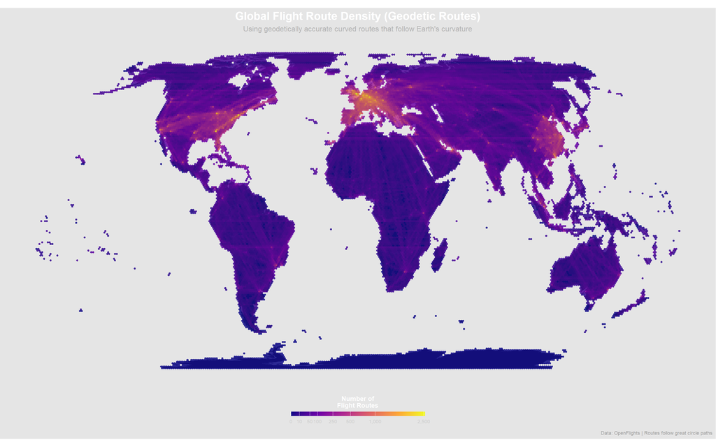

```r
# Create the map with grey background
map_geodetic <- ggplot() +

  # World boundaries
  geom_sf(
    data = world,
    fill = "gray20",
    color = "gray40",
    linewidth = 0.1
  ) +

  # Hexagonal grid with route counts
  geom_sf(
    data = hexgrid_world_geodetic_cnt,
    aes(fill = nm_rts),
    color = NA,
    alpha = 0.85
  ) +

  # Color scale
  scale_fill_viridis_c(
    option = "plasma",
    name = "Number of\nFlight Routes",
    trans = "sqrt",
    breaks = c(0, 10, 50, 100, 250, 500, 1000, 2500),
    labels = comma,
    guide = guide_colorbar(
      barwidth = 15,
      barheight = 0.5,
      title.position = "top",
      title.hjust = 0.5
    )
  ) +

  # Labels
  labs(
    title = "Global Flight Route Density (Geodetic Routes)",
    subtitle = "Using geodetically accurate curved routes that follow Earth's curvature",
    caption = "Data: OpenFlights | Routes follow great circle paths"
  ) +

  # Theme with grey background
  theme_minimal() +
  theme(
    plot.title = element_text(size = 18, face = "bold", hjust = 0.5, color = "white"),
    plot.subtitle = element_text(size = 12, hjust = 0.5, color = "gray70"),
    plot.caption = element_text(size = 8, color = "gray60", hjust = 1),
    legend.position = "bottom",
    legend.title = element_text(size = 10, face = "bold", color = "white"),
    legend.text = element_text(size = 8, color = "gray80"),
    panel.grid = element_blank(),
    axis.text = element_blank(),
    axis.title = element_blank(),
    plot.background = element_rect(fill = "gray90", color = NA),
    panel.background = element_rect(fill = "gray90", color = NA)
  ) +

  coord_sf(crs = 8857)

# Display the map
print(map_geodetic)
```

### Save High-Quality Outputs

```r
# Save as PNG with grey background
ggsave(
  "output/flight_route_density_map_geodetic.png",
  plot = map_geodetic,
  width = 16,
  height = 10,
  dpi = 300,
  bg = "gray15"
)
```

[output not shown]

```r
# Save as PDF
ggsave(
  "output/flight_route_density_map_geodetic_print.pdf",
  plot = map_geodetic,
  width = 16,
  height = 10,
  device = "pdf"
)

cat("✓ Maps saved successfully!\n")
```

```
✓ Maps saved successfully!
```

```r
cat("  - flight_route_density_map_geodetic.png (300 DPI)\n")
```

```
  - flight_route_density_map_geodetic.png (300 DPI)
```

```r
cat("  - flight_route_density_map_geodetic_print.pdf\n")
```

```
  - flight_route_density_map_geodetic_print.pdf
```

## 🎉 Success!

You’ve successfully created a professional flight route density visualization!

### What the Map Shows

**Bright colors (yellow/pink)** indicate: - High concentration of flight routes - Major aviation hubs - Well-connected regions

**Dark colors (purple/blue)** indicate: - Few flight routes - Remote or less connected regions